# Detecting Wafer Defects

## Assumptions

- We get a single reference image without defects and another image to inspect.
- The reference and inspected images are not fully aligned.
- The transformation between the reference and inspected is only planar 2D affine. This means we assume no 3D movement of the wafer or camera which can cause projective transformation.
- To have a robust alignment in the presence of defects we use 2 stages. At the first stage we use features based alignment and on the second stage we use photometric based alignment.
- We assume there are some features that we can find and match. That means that a completely blank image or a very large defect which cover the whole image will fail to align.

## Code

- Written in Python 3.7
- To install dependencies: `pip install numpy opencv-contrib-python matplotlib scikit-image`

```python
import os
import warnings
import numpy as np
from skimage import measure, filters
import matplotlib.pyplot as plt
import cv2
np.set_printoptions(formatter={'float': lambda x: "{0:0.3f}".format(x)})
```

## Loading the data

```python
# Read data
image_folder = "./images"
data = [
    {"reference": cv2.imread(os.path.join(image_folder, "defective_examples/case1_reference_image.tif"), cv2.IMREAD_UNCHANGED),
     "inspected": cv2.imread(os.path.join(image_folder, "defective_examples/case1_inspected_image.tif"), cv2.IMREAD_UNCHANGED)},
    {"reference": cv2.imread(os.path.join(image_folder, "defective_examples/case2_reference_image.tif"), cv2.IMREAD_UNCHANGED),
     "inspected": cv2.imread(os.path.join(image_folder, "defective_examples/case2_inspected_image.tif"), cv2.IMREAD_UNCHANGED)},
    {"reference": cv2.imread(os.path.join(image_folder, "non_defective_examples/case3_reference_image.tif"), cv2.IMREAD_UNCHANGED),
     "inspected": cv2.imread(os.path.join(image_folder, "non_defective_examples/case3_inspected_image.tif"), cv2.IMREAD_UNCHANGED)}
]
defects_gt = [
    np.array([[149, 334], [82, 245], [97, 82]]),  # (x, y)
    np.array([[344, 265], [105, 108], [80, 262]]),
    None]
```

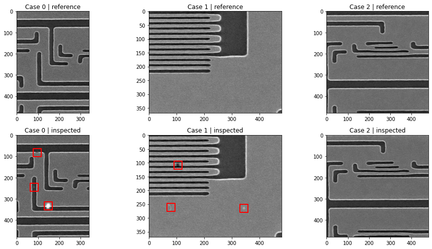

```python
# Plot input
fig, axes = plt.subplots(2, 3, figsize=(15, 7), tight_layout=True)
for case_ind, case in enumerate(data):
    for im_ind, im_title in enumerate(("reference", "inspected")):
        ax = axes[im_ind, case_ind]
        ax.imshow(data[case_ind][im_title], cmap='gray')
        ax.set_title(f"Case {case_ind} | {im_title}")
        if im_title == "inspected" and defects_gt[case_ind] is not None:
            ax.scatter(defects_gt[case_ind][:, 0], defects_gt[case_ind][:, 1],
                       facecolors='none', edgecolors='r', marker="s", s=250, linewidth=2)
```

## Image Denoising

Because wafer images contain a lot of repeated patterns we use non-local means for denoising. We make sure not to denoise too aggresively to avoid smoothing the defects data.

```python
for case_ind, case in enumerate(data):
    for key in ("reference", "inspected"):
        data[case_ind][f"{key}_denoised"] = cv2.fastNlMeansDenoising(data[case_ind][key], None, h=7,
                                                                     templateWindowSize=7, searchWindowSize=51)
```

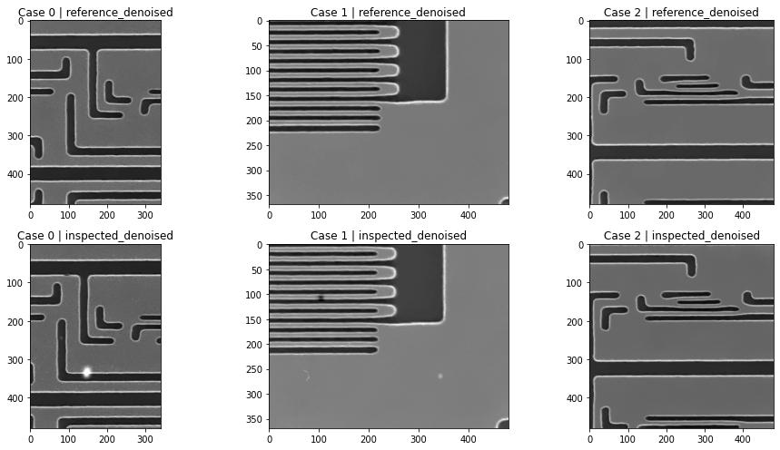

```python
# Plot input
fig, axes = plt.subplots(2, 3, figsize=(15, 7), tight_layout=True)
for case_ind, case in enumerate(data):
    for im_ind, im_title in enumerate(("reference_denoised", "inspected_denoised")):
        ax = axes[im_ind, case_ind]
        ax.imshow(data[case_ind][im_title], cmap='gray')
        ax.set_title(f"Case {case_ind} | {im_title}")
```

## Image Alignment

### 1) Align images using ORB features matching

In the initial alignment stage we use feature-based method because the images can have large misalignment and we want to handle cases of large defects.

We estimate an affine transformation between the images using RANSAC, which allows us to align the images even in the presence of many outliers.

```python
# Detect ORB features and compute descriptors.
orb = cv2.ORB_create(nfeatures=1000)
for case_ind, case in enumerate(data):
    kps1, desc1 = orb.detectAndCompute(case["reference_denoised"], None)
    kps2, desc2 = orb.detectAndCompute(case["inspected_denoised"], None)

    # Match features
    matcher = cv2.DescriptorMatcher_create(cv2.DESCRIPTOR_MATCHER_BRUTEFORCE_HAMMING)
    matches = matcher.match(desc1, desc2, None)

    # Sort matches by score
    matches.sort(key=lambda x: x.distance, reverse=False)

    # Extract location of good matches
    points1 = np.zeros((len(matches), 2), dtype=np.float32)
    points2 = np.zeros((len(matches), 2), dtype=np.float32)
    for i, match in enumerate(matches):
        points1[i, :] = kps1[match.queryIdx].pt
        points2[i, :] = kps2[match.trainIdx].pt

    # Find homography
    transform, inliers = cv2.estimateAffine2D(points1, points2, inliers=None, method=cv2.RANSAC,
                                              ransacReprojThreshold=2, maxIters=10000)

    # Keep data for further processing and plots
    data[case_ind]["kps_reference"] = kps1
    data[case_ind]["kps_inspected"] = kps2
    data[case_ind]["matches"] = matches
    data[case_ind]["inliers"] = inliers
    data[case_ind]["transform0"] = transform
    data[case_ind]["inspected_aligned0"] = cv2.warpAffine(case["inspected_denoised"], transform,
                                                          case["inspected"].shape[::-1],
                                                          flags=cv2.INTER_AREA + cv2.WARP_INVERSE_MAP)
    print(f"Case #{case_ind} - initial transformation:\n{transform}")
```

```
Case #0 - initial transformation:
[[1.002 -0.011 -22.023]
 [-0.002 0.995 4.713]]
Case #1 - initial transformation:
[[0.991 0.011 -5.614]
 [0.012 0.999 -7.450]]
Case #2 - initial transformation:
[[0.998 0.001 4.206]
 [-0.002 0.991 -18.562]]
```

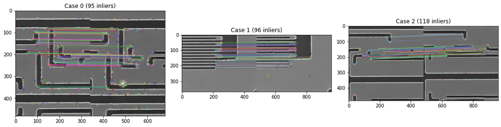

```python
# Draw matches
fig, axes = plt.subplots(1, 3, figsize=(15, 10), tight_layout=True)
for case_ind, case in enumerate(data):
    im1 = cv2.cvtColor(case["reference_denoised"], cv2.COLOR_GRAY2BGR)
    im2 = cv2.cvtColor(case["inspected_denoised"], cv2.COLOR_GRAY2BGR)
    # Extract only the inliers matches
    matches_inliers = [x for i, x in enumerate(case["matches"]) if case["inliers"][i, 0] == 1]
    im_matches = cv2.drawMatches(im1, case["kps_reference"], im2, case["kps_inspected"], matches_inliers, None)
    ax = axes[case_ind]
    ax.imshow(im_matches)
    ax.set_title(f"Case {case_ind} ({len(matches_inliers)} inliers)")
```

### 2) Refine alignment images using ECC (Enhanced Correlation Coefficient)

In this stage we use the full intensity data in order to align the images based on a photometric loss. This method gives better alignment given that we have a good initial guess from the previous features-based stage.

```python
# 2. Refine alignment images using ECC (Enhanced Correlation Coefficient)
# This works well only if we have a good initial guess
number_of_iterations = 200
termination_eps = 1e-6
criteria = (cv2.TERM_CRITERIA_EPS | cv2.TERM_CRITERIA_COUNT, number_of_iterations,  termination_eps)
for case_ind, case in enumerate(data):
    # Find transformation between inspected and reference, based on previous feautres-based transformation
    warp_matrix_init = data[case_ind]["transform0"].copy().astype(np.float32)
    mask = np.ones_like(case["inspected"]).astype(np.uint8) * 255
    retval, warp_mat = cv2.findTransformECC(
        case["reference_denoised"], case["inspected_denoised"], warp_matrix_init,
        cv2.MOTION_AFFINE, criteria, inputMask=mask, gaussFiltSize=3)
    data[case_ind]["transform"] = warp_mat
    data[case_ind]["inspected_aligned"] = cv2.warpAffine(case["inspected_denoised"], warp_mat,
                                                         case["inspected"].shape[::-1],
                                                         flags=cv2.INTER_AREA + cv2.WARP_INVERSE_MAP)

    # Keep a mask to mark regions which are missing in the inspected image
    data[case_ind]["mask_aligned"] = cv2.warpAffine(np.ones_like(case["inspected"]), warp_mat,
                                                    case["inspected"].shape[::-1],
                                                    flags=cv2.INTER_NEAREST + cv2.WARP_INVERSE_MAP)
    data[case_ind]["mask_aligned"] = cv2.erode(data[case_ind]["mask_aligned"], kernel=np.ones((3, 3)))

    print(f"Case #{case_ind} - final transformation:\n{warp_mat}")
```

```
Case #0 - final transformation:
[[1.001 -0.001 -23.336]
 [-0.000 1.000 4.211]]
Case #1 - final transformation:
[[1.002 0.000 -6.459]
 [0.001 1.000 -5.168]]
Case #2 - final transformation:
[[0.999 0.000 3.949]
 [-0.000 0.999 -20.394]]
```

We make sure the ECC based transformation is close to the initial one to avoid issues when the inspected image contains many large defects which can ruin the photometric loss.

```python
# Compute distance between initial transformation and final one
max_diff_th = 5  # [pixels]
pt = np.array([[1], [1], [1]], dtype=np.float32)
for case_ind, case in enumerate(data):
    t_init = np.dot(data[case_ind]["transform0"], pt).ravel()
    t_final = np.dot(data[case_ind]["transform"], pt).ravel()
    dist = np.linalg.norm(t_final - t_init, ord=2)
    print(f"Case #{case_ind}: distance between transformations is {dist:.2f} pixels")
    if dist > max_diff_th:
        warnings.warn(f"Case #{case_ind} - Large difference of {dist:.2f} pixels between 1st and 2nd alignment!")
```

```
Case #0: distance between transformations is 1.40 pixels
Case #1: distance between transformations is 2.42 pixels
Case #2: distance between transformations is 1.84 pixels
```

In the following plot we can see the benefit of doing photometric based alignment compared to features based.

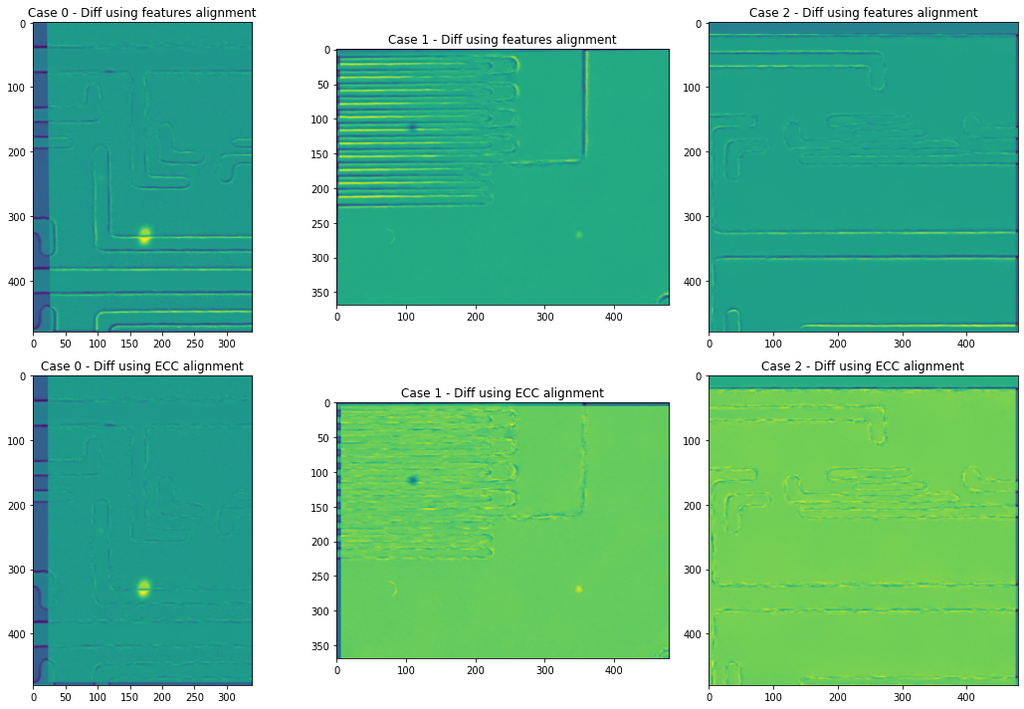

```python
# Plot the difference results using features and ECC.
fig, axes = plt.subplots(2, 3, figsize=(15, 10), tight_layout=True)
for case_ind, case in enumerate(data):
    ax = axes[0, case_ind]
    ax.imshow(case["inspected_aligned0"].astype(np.float32) - case["reference_denoised"].astype(np.float32))
    ax.set_title(f"Case {case_ind} - Diff using features alignment")
    ax = axes[1, case_ind]
    ax.imshow(case["inspected_aligned"].astype(np.float32) - case["reference_denoised"].astype(np.float32))
    ax.set_title(f"Case {case_ind} - Diff using ECC alignment")
```

## Find Defects

### Compute Gradient

The purpose of this stage is to handle separately pixels near edges because of aligment issues.

We create a binary mask which marks all the edge pixels based on the reference image. We use the denoised reference image to remove standard image noise (shot-noise, read-noise, etc.). Ideally this would be achieved by median across multiple reference images or longer exposure time.

```python
# Compute gradient on reference image
grad_th = 100  # Binary threshold for the gradient mask
for case_ind, case in enumerate(data):
    dx = cv2.Sobel(case["reference_denoised"], cv2.CV_32F, dx=1, dy=0, ksize=3)
    dy = cv2.Sobel(case["reference_denoised"], cv2.CV_32F, dx=0, dy=1, ksize=3)
    grad = np.sqrt(dx**2 + dy**2)
    grad_mask = (grad > grad_th).astype(np.uint8)

    # Apply morphological operations to smooth the mask
    kernel = np.ones((3, 3), dtype=np.uint8)
    grad_mask = cv2.dilate(grad_mask, kernel, iterations=1)
    grad_mask = cv2.morphologyEx(grad_mask, cv2.MORPH_OPEN, kernel)

    # Keep in data dictionary
    data[case_ind]["grad"] = grad
    data[case_ind]["grad_mask"] = grad_mask
```

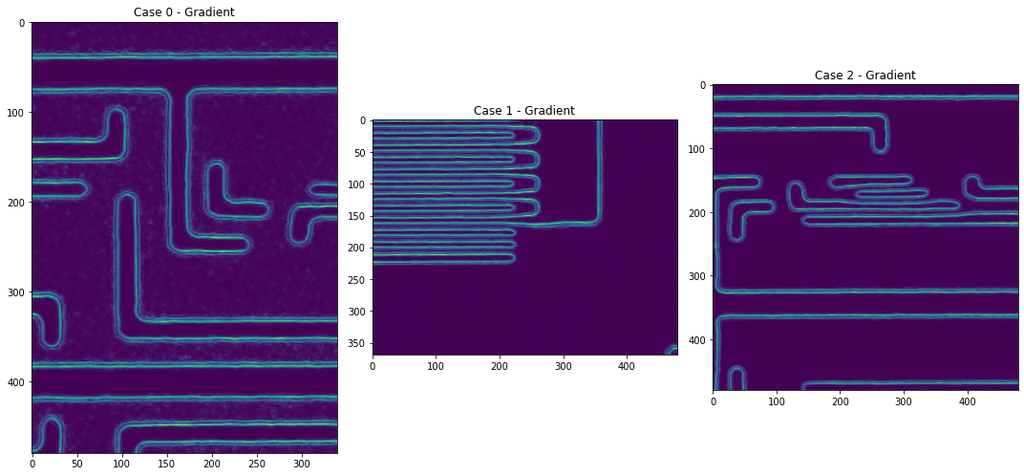

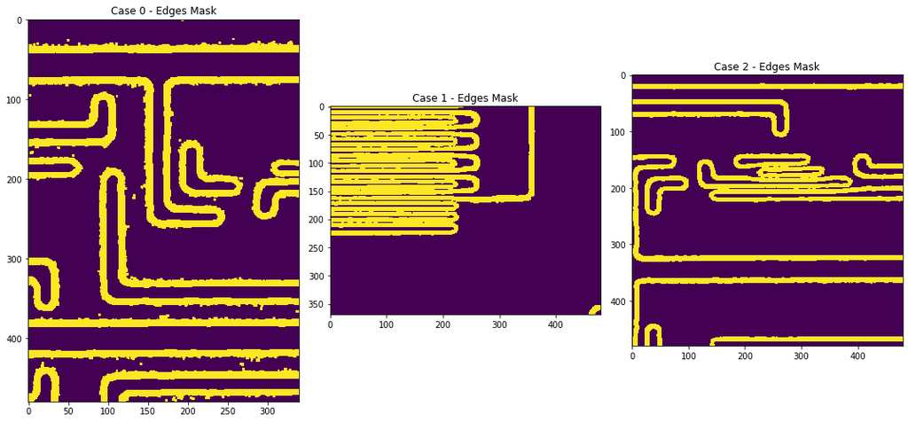

```python
# Plot
fig, axes = plt.subplots(1, 3, figsize=(15, 10), tight_layout=True)
for case_ind, case in enumerate(data):
    ax = axes[case_ind]
    ax.imshow(case["grad"])
    ax.set_title(f"Case {case_ind} - Gradient")

fig, axes = plt.subplots(1, 3, figsize=(15, 10), tight_layout=True)
for case_ind, case in enumerate(data):
    ax = axes[case_ind]
    ax.imshow(case["grad_mask"], interpolation="none")
    ax.set_title(f"Case {case_ind} - Edges Mask")
```

## Compute Difference

We compute the difference between the reference image and the aligned inspected image.

```python
# Compute difference
for case_ind, case in enumerate(data):
    data[case_ind]["diff_unmasked"] = case["inspected_aligned"].astype(np.float32) - case["reference_denoised"].astype(np.float32)
    data[case_ind]["diff_unmasked"][case["mask_aligned"] == 0] = np.nan  # Put NaN in missing image borders
    data[case_ind]["diff_masked"] = data[case_ind]["diff_unmasked"].copy()
    data[case_ind]["diff_masked"][case["grad_mask"] == 1] = np.nan  # Put NaN in edges
```

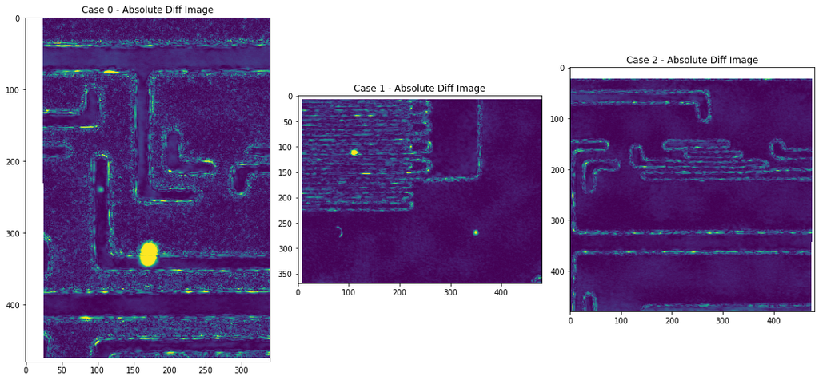

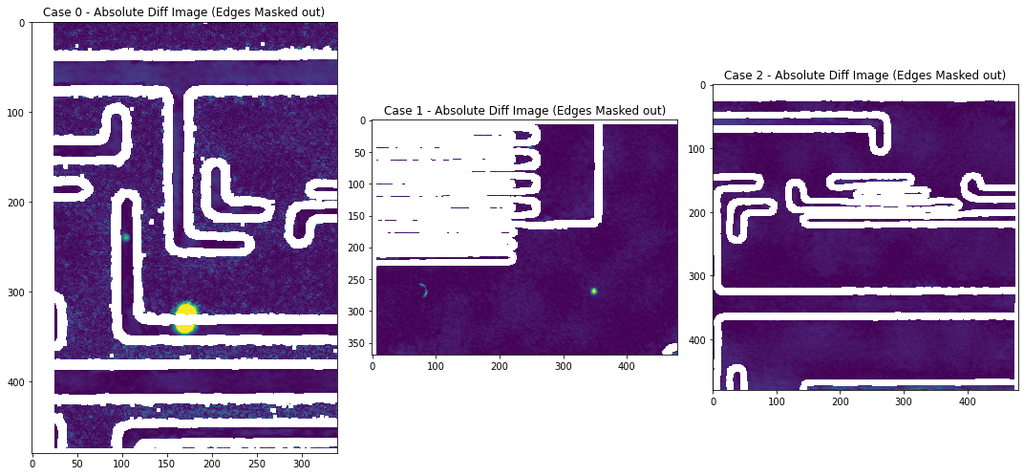

```python
# Plot
fig, axes = plt.subplots(1, 3, figsize=(15, 10), tight_layout=True)
for case_ind, case in enumerate(data):
    ax = axes[case_ind]
    ax.imshow(np.abs(case["diff_unmasked"]), vmax=50)
    ax.set_title(f"Case {case_ind} - Absolute Diff Image")

fig, axes = plt.subplots(1, 3, figsize=(15, 10), tight_layout=True)
for case_ind, case in enumerate(data):
    ax = axes[case_ind]
    ax.imshow(np.abs(case["diff_masked"]), vmax=50)
    ax.set_title(f"Case {case_ind} - Absolute Diff Image (Edges Masked out)")
```

## Detect defects

To detect the defects we separate between the edge masked and non-masked difference. In the masked difference image we use lower threshold because we assume all the alignment issues are already masked out and we would find only defects. For the unmasked difference, we use a higher threshold because we can also have false detection on edges which did not align correctly. Additionally, we use hystersis threshold to reduce the chance for false detection.

In this stage we also ignore blobs below certain size (5 pixels). Reducing this requirment would cause us to detect few small false defects.

```python
min_area = 5  # We ignore detections below this number of pixels
# We use threshold of 25 of non-edges regions and 90 for edges
for th, suffix in zip([35, 90], ["_masked", "_unmasked"]):
    for case_ind, case in enumerate(data):
        # Create binary image
        bw = np.abs(case["diff" + suffix])
        bw[~np.isfinite(bw)] = 0
        bw = filters.apply_hysteresis_threshold(bw, low=25, high=th)

        # Gather labels statistics
        labels_map = measure.label(bw)
        stats = measure.regionprops(labels_map, intensity_image=np.abs(case["diff" + suffix]))
        stats = [x for x in stats if x.area > min_area]

        # Remove small labels and sort by intensity
        labels = [x.label for x in stats]
        intensity = [x.mean_intensity for x in stats]
        labels = [x for _, x in sorted(zip(intensity, labels))]  # Sort by intensity
        labels_out = np.zeros_like(labels_map, dtype=np.int)
        label_ind = 1
        for label in labels:
            labels_out[labels_map == label] = label_ind
            label_ind += 1
        data[case_ind]["labels" + suffix] = labels_out
        data[case_ind]["stats" + suffix] = measure.regionprops(labels_out,
                                                               intensity_image=np.abs(case["diff" + suffix]))

# Merge labels
for case_ind, case in enumerate(data):
    bw = np.logical_or(data[case_ind]["labels_unmasked"] > 0, data[case_ind]["labels_masked"] > 0)
    labels_map = measure.label(bw)
    stats = measure.regionprops(labels_map, intensity_image=np.abs(case["diff_unmasked"]))
    data[case_ind]["labels"] = labels_map
    data[case_ind]["stats"] = stats
```

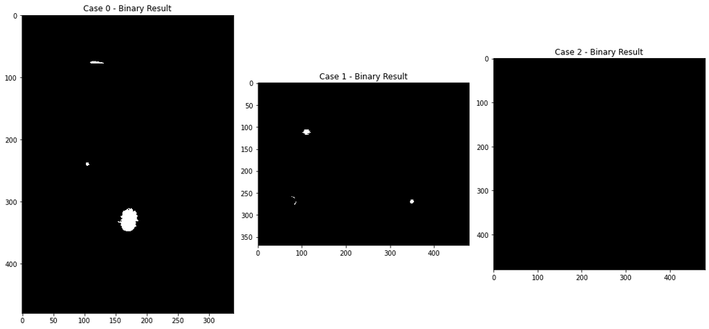

```python
# Plot
fig, axes = plt.subplots(1, 3, figsize=(15, 10), tight_layout=True)
for case_ind, case in enumerate(data):
    ax = axes[case_ind]
    ax.imshow(case["labels"] > 0, interpolation="None", cmap='gray')
    ax.set_title(f"Case {case_ind} - Binary Result")
```

```
Case #0 - 3 defects
  Defect #0 | (x,y)=[119  77] | area: 85 pixels | Mean intensity: 70.5
  Defect #1 | (x,y)=[105 240] | area: 20 pixels | Mean intensity: 30.1
  Defect #2 | (x,y)=[171 330] | area: 789 pixels | Mean intensity: 85.6
Case #1 - 4 defects
  Defect #0 | (x,y)=[110 112] | area: 151 pixels | Mean intensity: 56.7
  Defect #1 | (x,y)=[ 80 260] | area: 9 pixels | Mean intensity: 33.9
  Defect #2 | (x,y)=[349 269] | area: 61 pixels | Mean intensity: 37.5
  Defect #3 | (x,y)=[ 85 272] | area: 12 pixels | Mean intensity: 36.1
Case #2 - 0 defects
```

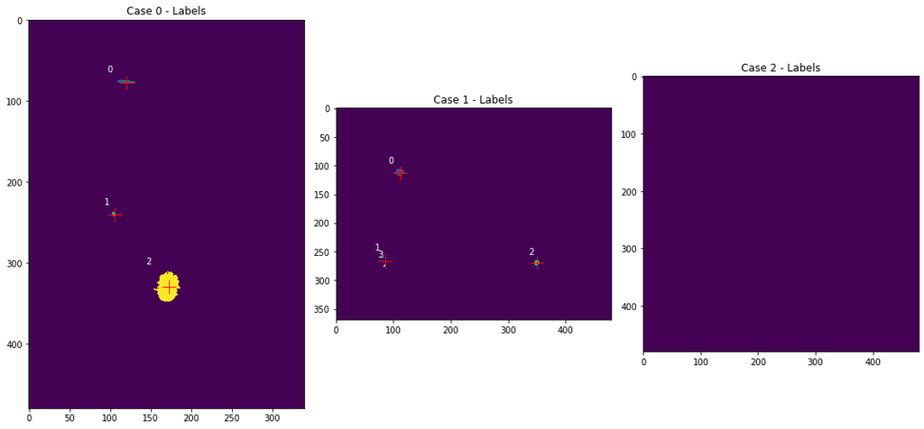

```python
# Show defects stats
for case_ind, case in enumerate(data):
    num_defects = len(case["stats"])
    print(f"Case #{case_ind} - {num_defects} defects")
    for defect_ind, defect in enumerate(case["stats"]):
        xy = np.round(defect.centroid[::-1]).astype(int)
        print(f"  Defect #{defect_ind} | (x,y)={xy} | area: {defect.area} pixels | Mean intensity: "
              f"{defect.mean_intensity:.1f}")

fig, axes = plt.subplots(1, 3, figsize=(15, 10), tight_layout=True)
for case_ind, case in enumerate(data):
    ax = axes[case_ind]
    ax.imshow(case["labels"], interpolation="None")
    ax.set_title(f"Case {case_ind} - Labels")
    for defect_ind, defect in enumerate(case["stats"]):
        min_row, min_col, max_row, max_col = defect.bbox
        ax.text(min_col-10, min_row-10, s=f"{defect_ind}", color="white")
    if defects_gt[case_ind] is not None:
        xy_hom = np.hstack((defects_gt[case_ind], np.ones((len(defects_gt), 1))))
        t = np.vstack((data[case_ind]["transform"], np.array([[0, 0, 1]])))
        xy = np.dot(np.linalg.inv(t), xy_hom.T).T
        ax.scatter(xy[:, 0], xy[:, 1], facecolors='red', marker="+", s=250, linewidth=1)
```

## Possible Improvements

### Alignment

- Split the image into smaller blocks and try to find better alignment for each block.

### Defects detection

- For a better reference image we should take a per-pixel median over multiple chips from each wafer. This will reduce the chance our reference image contains any defact and will also reduce the image noise and the manufacturing variability which are not necessarily defects.
- Separate between bright over dark defects and dark over bright.
- The defects detection which was presented here is based on hand-tuned parameters and contains some heuristic. Given more labeled data we should probably use a learning-based classification on the difference image.